# EDLD Winter 2020 Lab 2

Jim Wright; Claire Zhang

1/15/2020

# Data Exploration Histograms

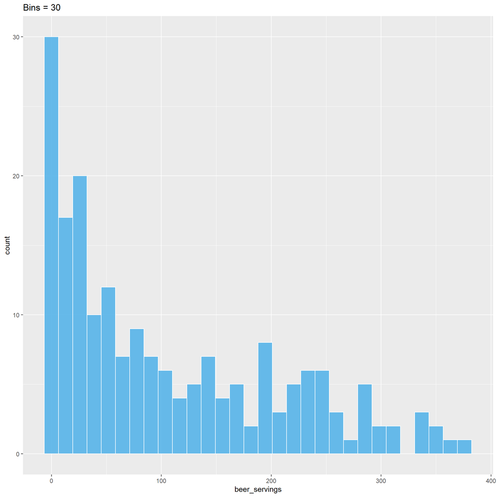

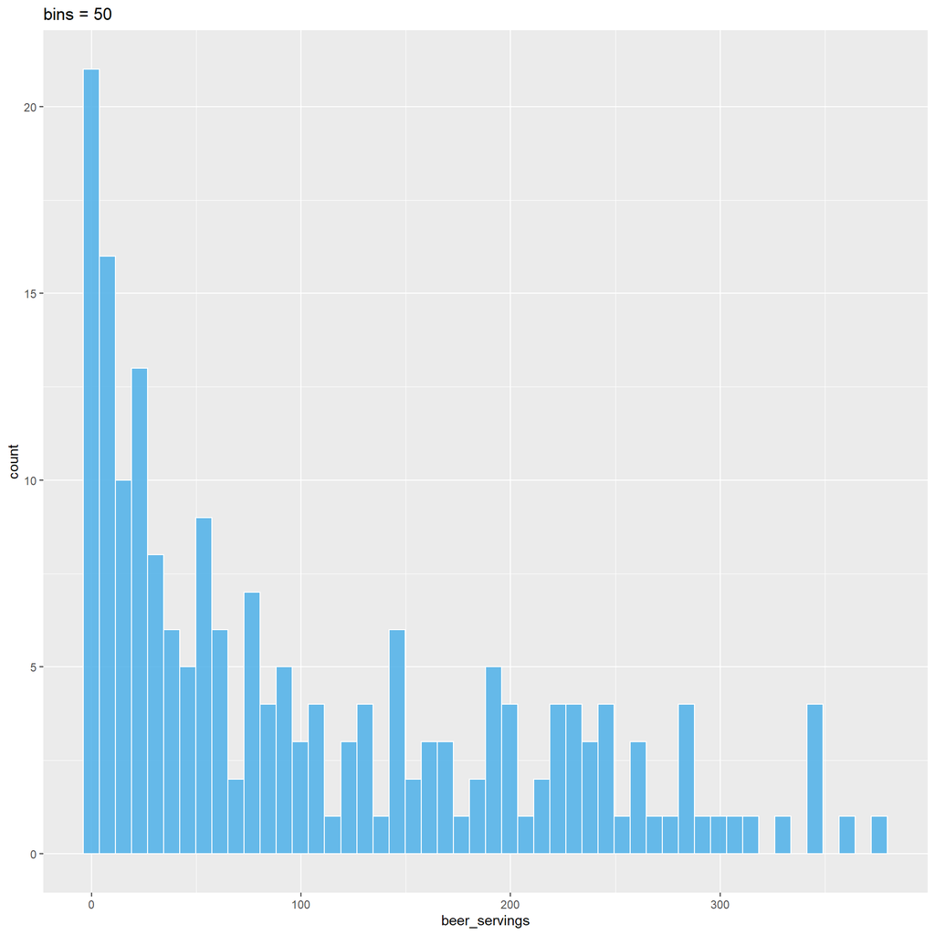

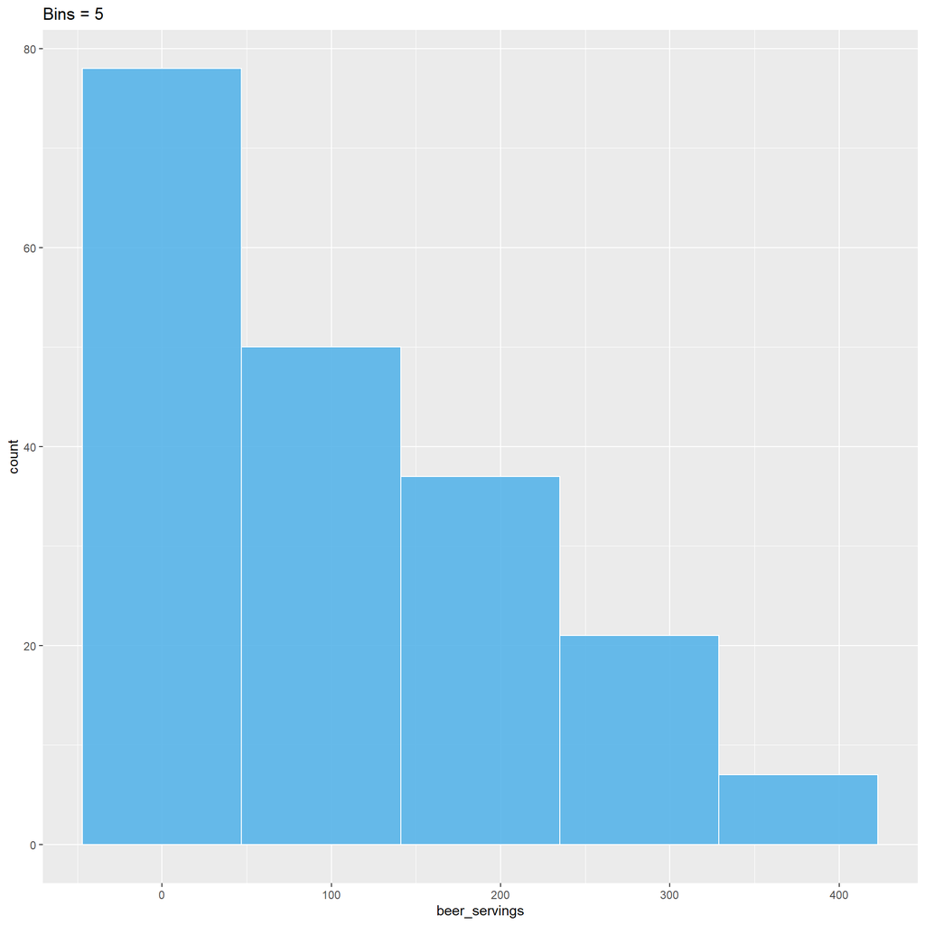

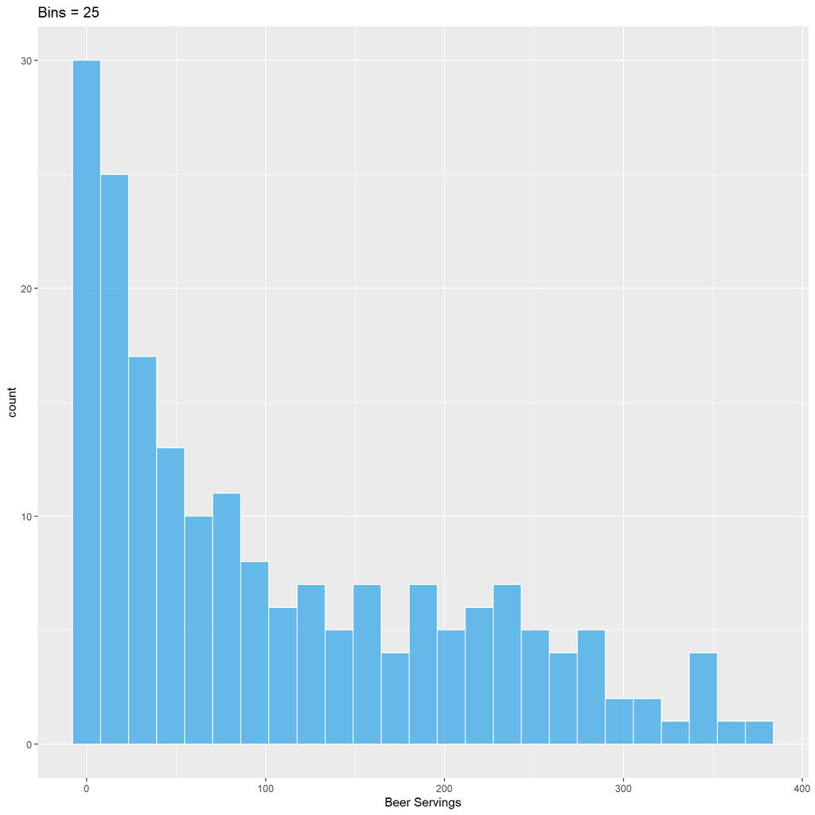

Jim: I believe the histogram of beer consumption with bins set at 25 is the superior option because the distribution is very positively skewed, so it provides a more clear explanation of how the lower end of the distribution varies.

# Data Exploration Density Plots

```
## # A tibble: 6 x 5
##   country    beer_servings spirit_servings wine_servings total_litres_of_p~
##   <chr>              <int>           <int>         <int>              <dbl>
## 1 Afghanist~             0               0             0                0
## 2 Albania               89             132            54                4.9
## 3 Algeria               25               0            14                0.7
## 4 Andorra              245             138           312               12.4
## 5 Angola               217              57            45                5.9
## 6 Antigua &~           102             128            45                4.9
```

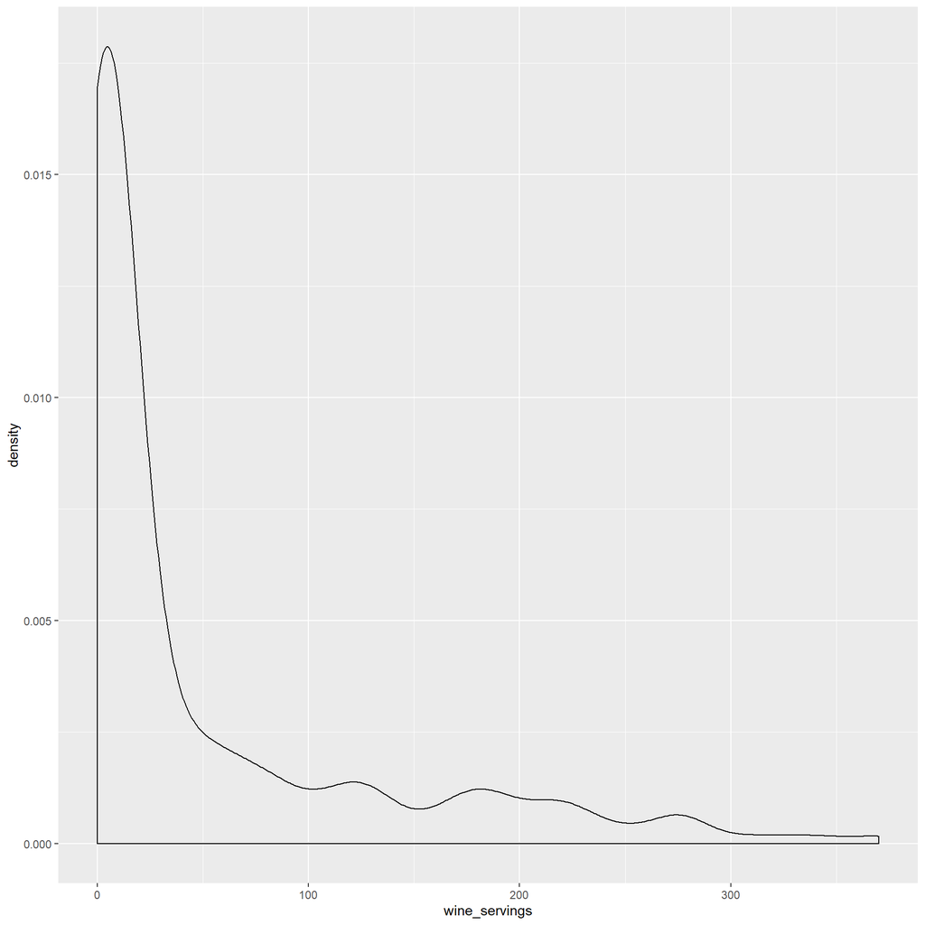

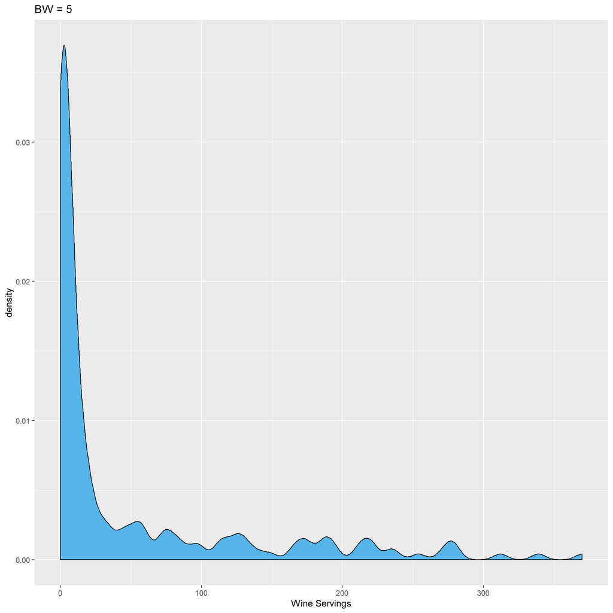

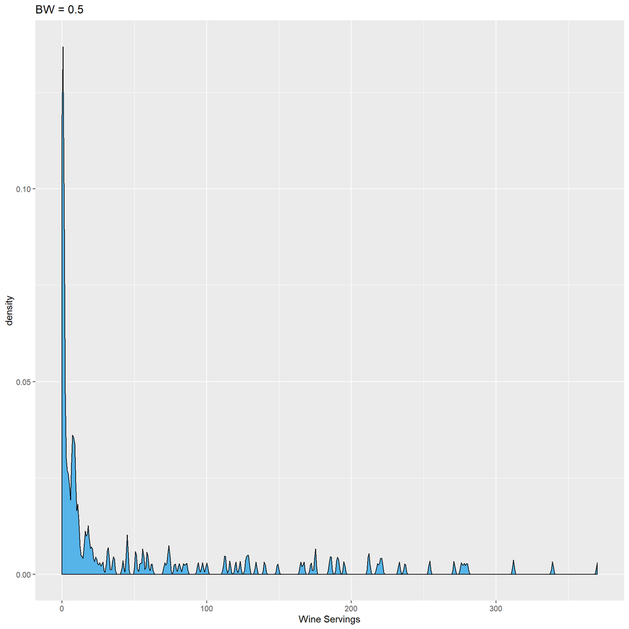

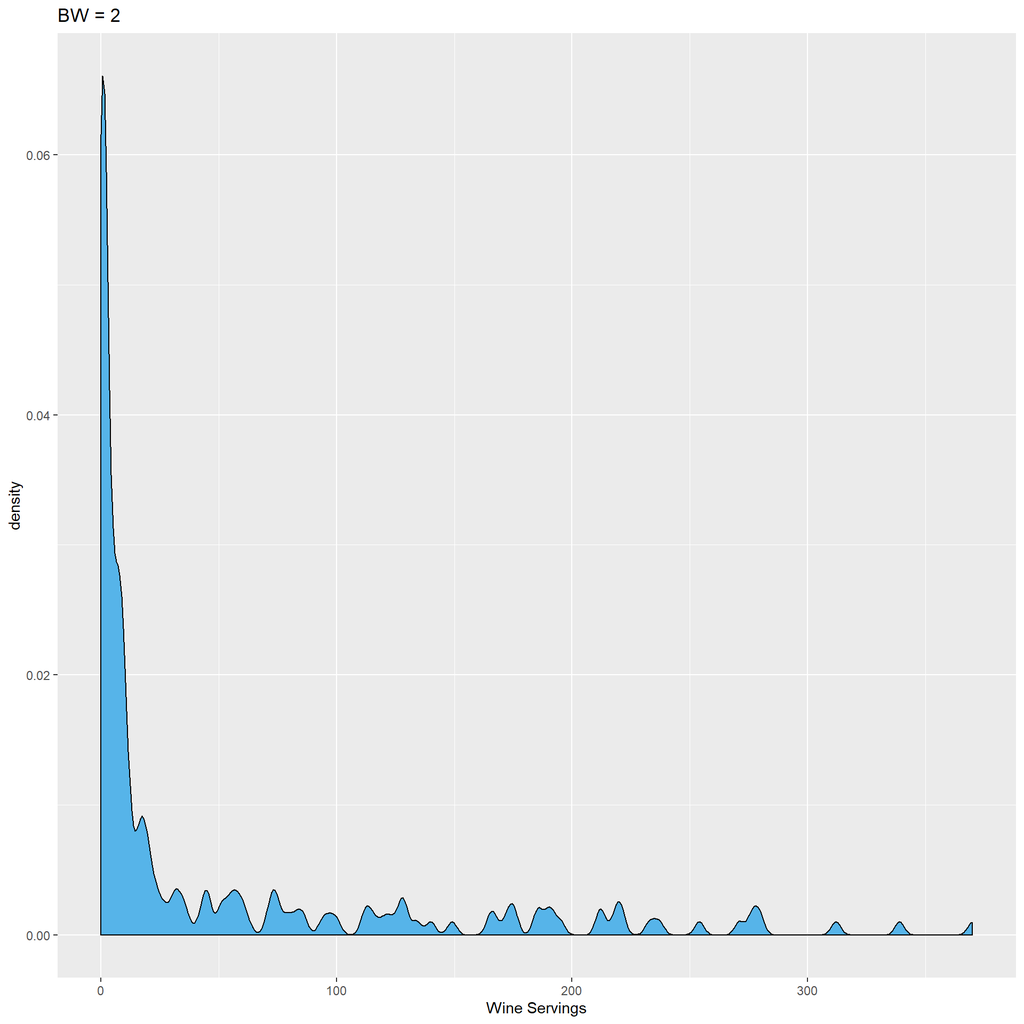

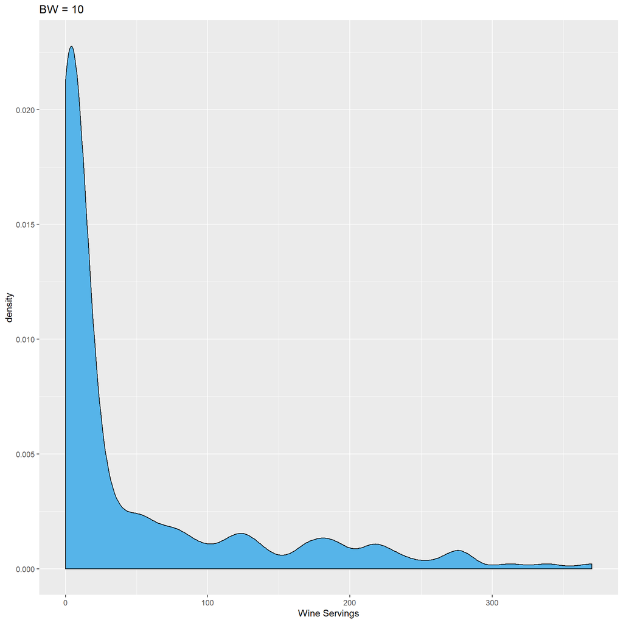

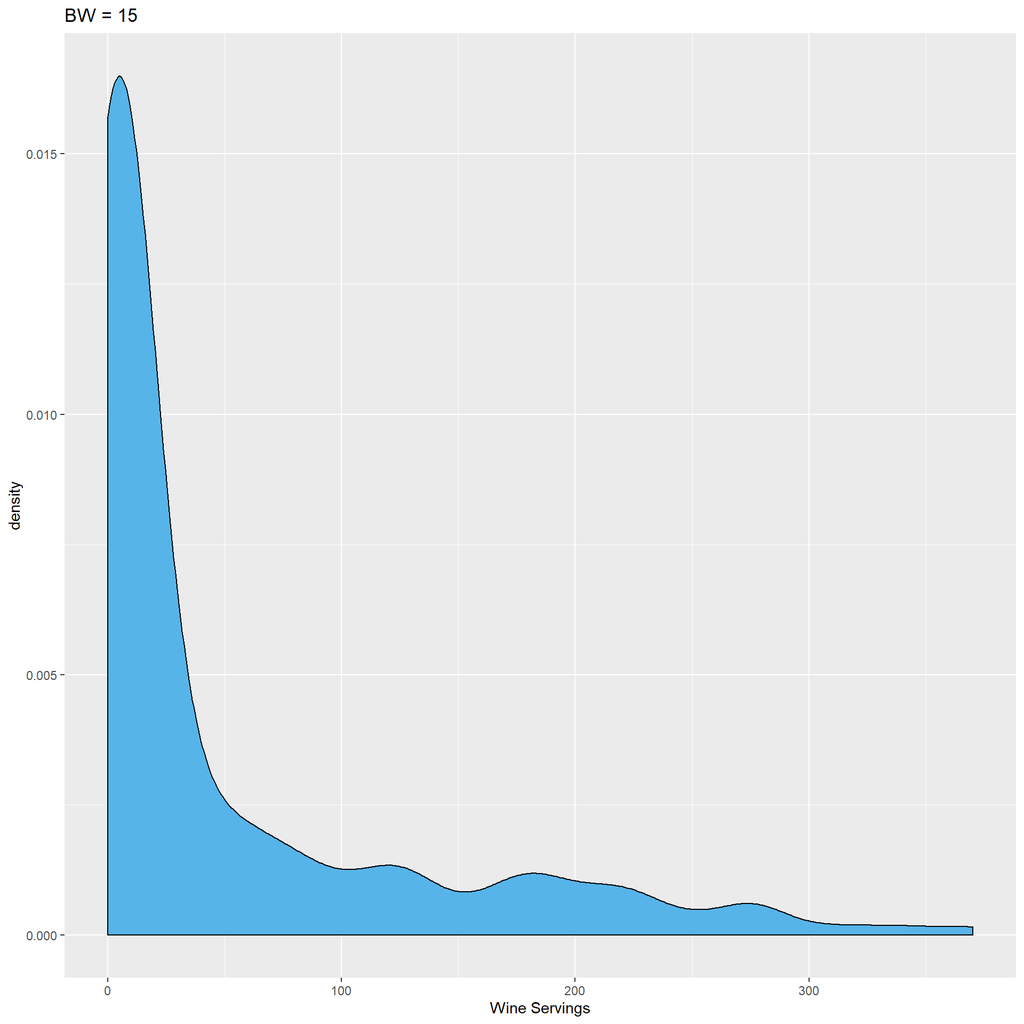

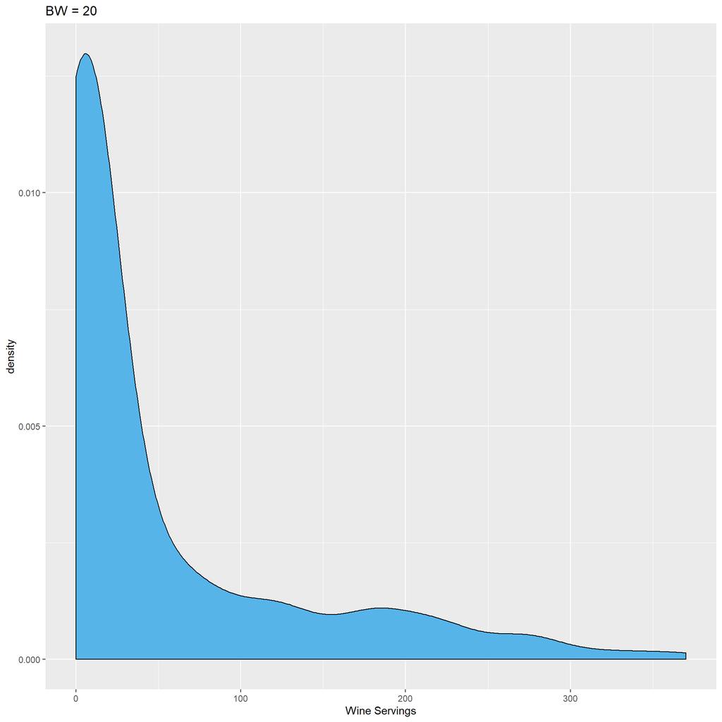

Jim: I believe having a larger binwidth (10 - 20) is preferrable for the density plots because it more clearly displays the concentration of wine consumption at lower servings. Similar to beer consumption, wine consumption is skewed positivley, so I think it is better to provide a more clear display of where the largest display of consumption is occuring.

## Explore the overall distribution of total alcohol consumed

1. Histogram
1. Play with the number of bins
2. Settle on a number of bins and provide a brief justification in text

Claire: firstly I want to investigate the total alcohol consumption by countries but I can only use geom_col as I have two columns. Still, it was a fun exploration, see graph “Top 20 Countries in Alcohol Consumption” below.

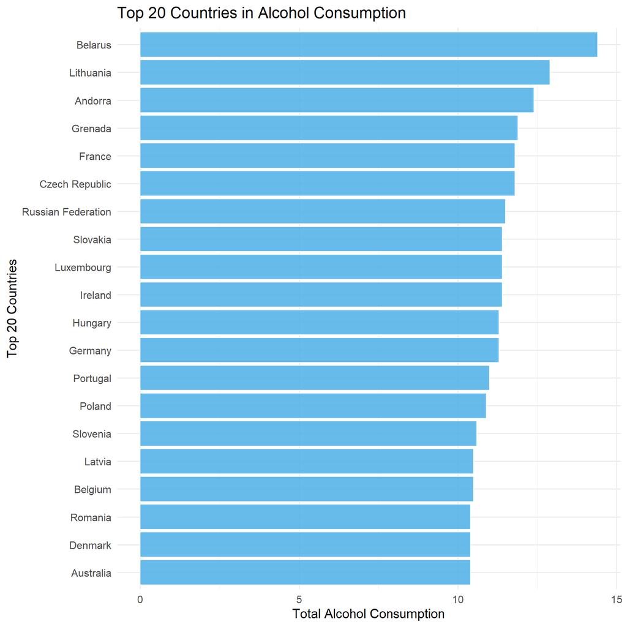

Then I set out to explore the geom_histogram. I played with the bins setting several times and found that if I set bins to 25, the graph looks nice as the scale of alcohol consumption is 0-15. However, as y-axis represents “count”, I don’t actually know how to interpret the graph.

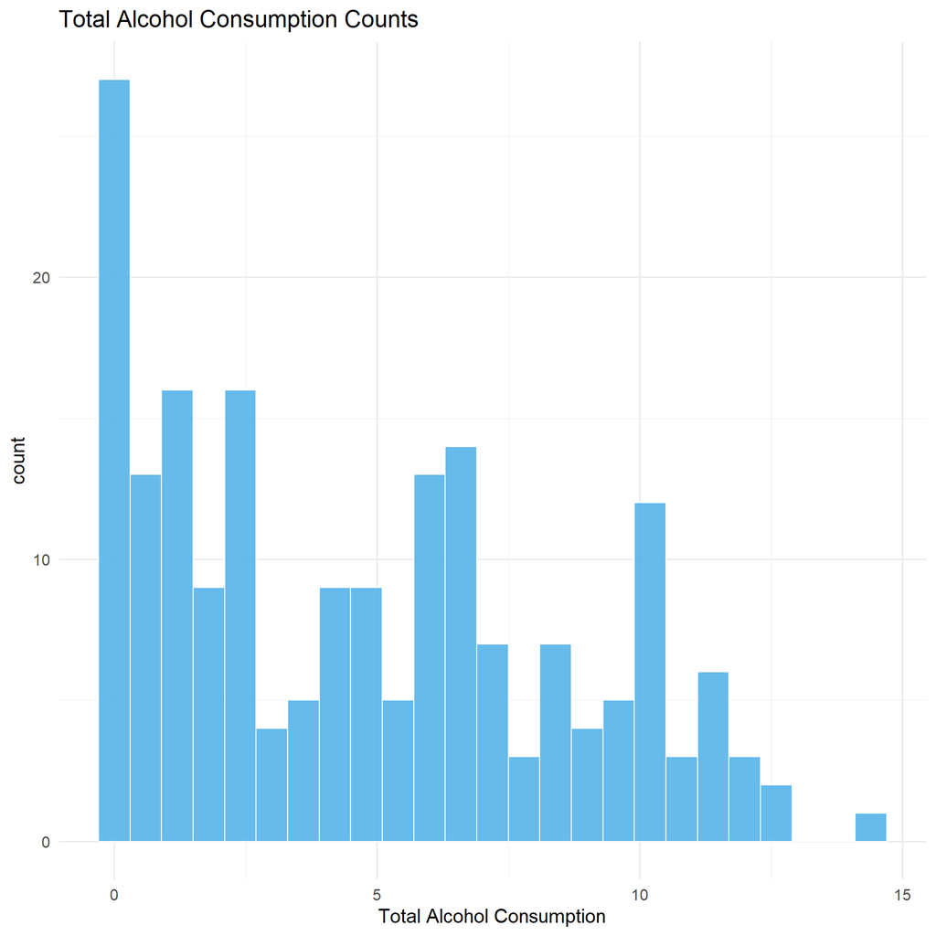

# Data Reorganization

```
## # A tibble: 6 x 5
##   country    beer_servings spirit_servings wine_servings total_litres_of_p~
##   <chr>              <int>           <int>         <int>              <dbl>
## 1 Afghanist~             0               0             0                0
## 2 Albania               89             132            54                4.9
## 3 Algeria               25               0            14                0.7
## 4 Andorra              245             138           312               12.4
## 5 Angola               217              57            45                5.9
## 6 Antigua &~           102             128            45                4.9
```

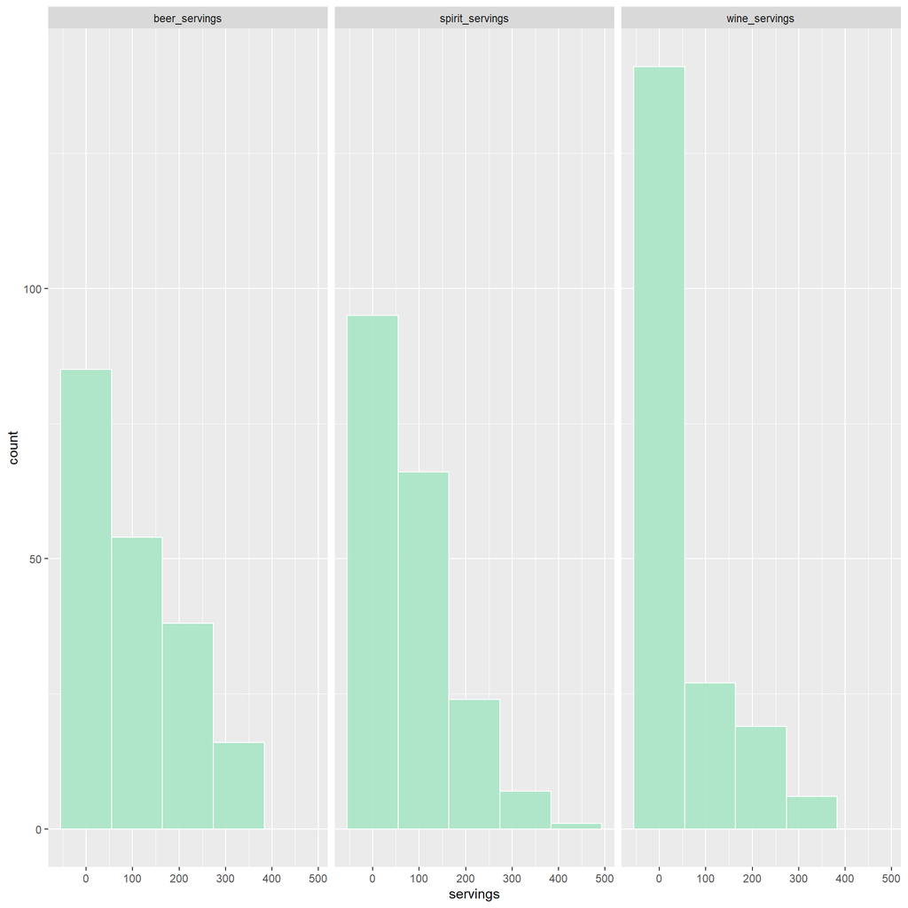

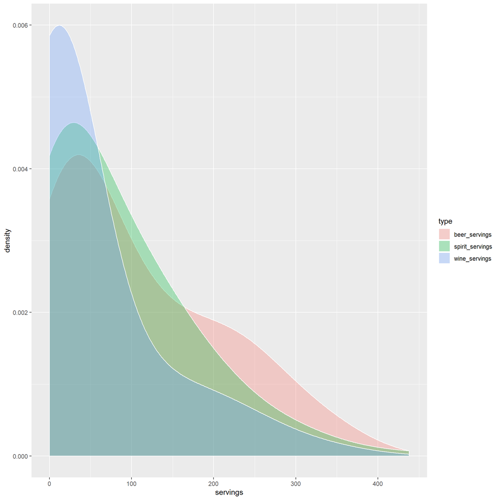

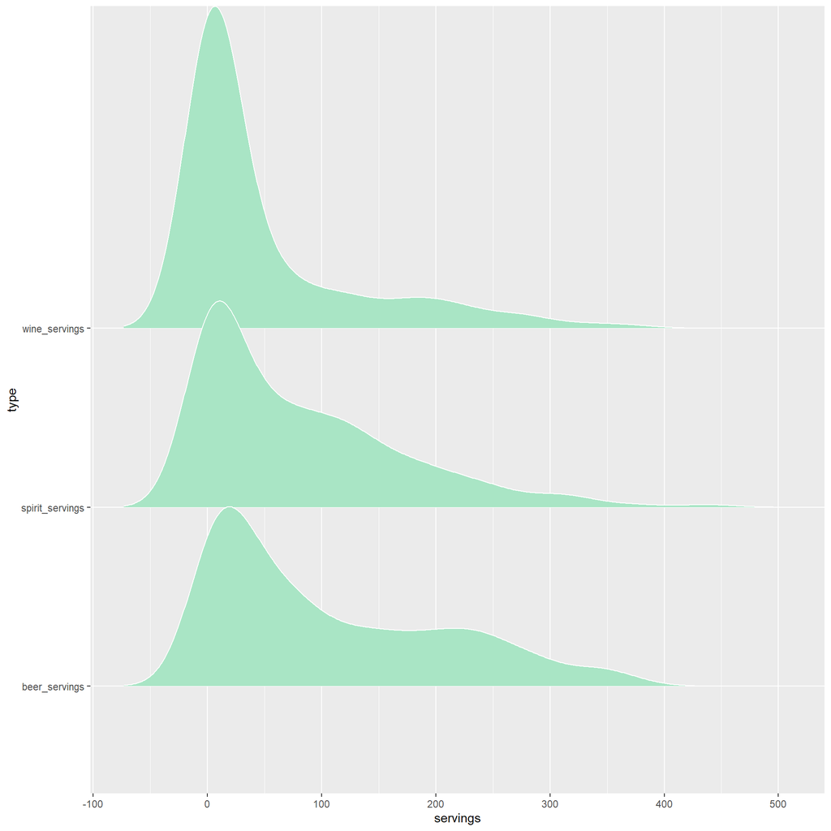

Jim: All three plots suggest the distribution of alcohol consumption is positively skewed across all three types of alcohol: beer, spirts, and wine. At the lowest level of servings consumed, wine is the most often consumed type of alcohol, while at higher consumption rates, beer appears to be the drink of choice.

# Reproduced Plot

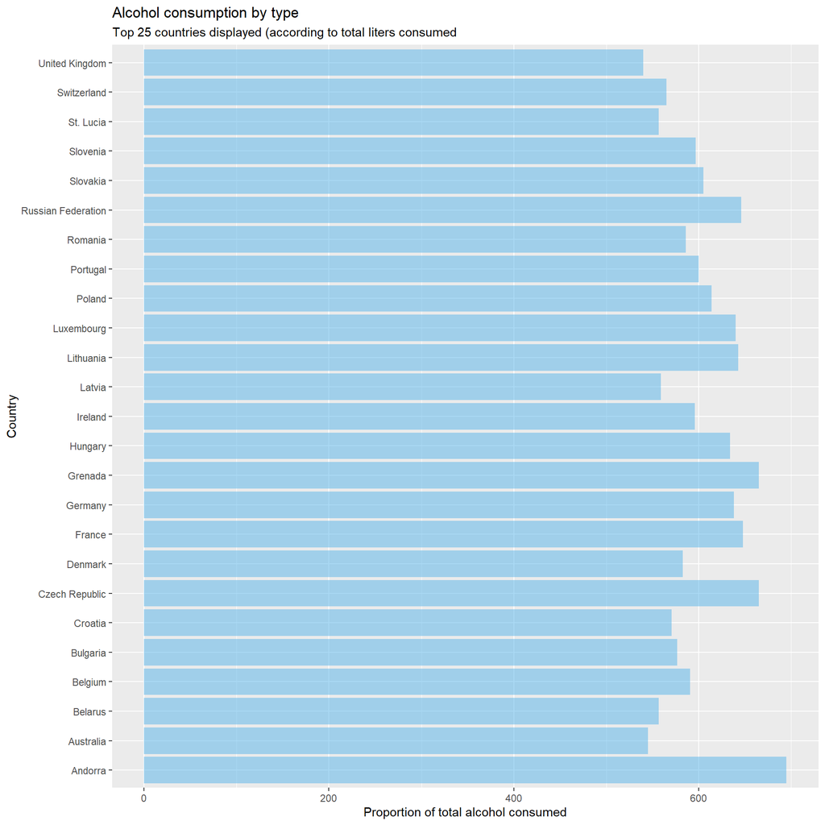

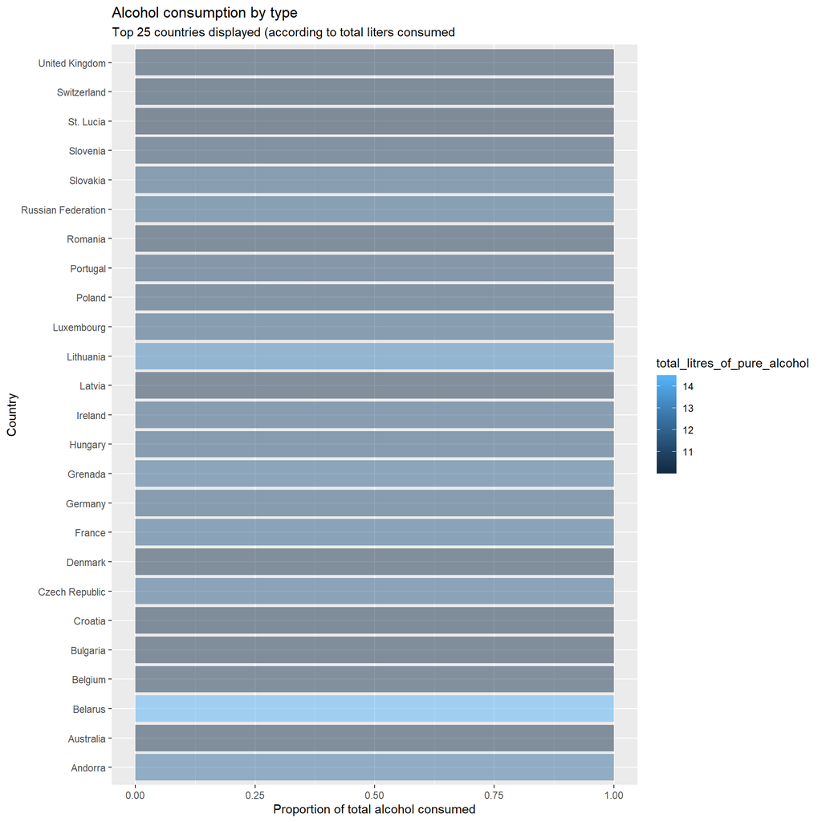

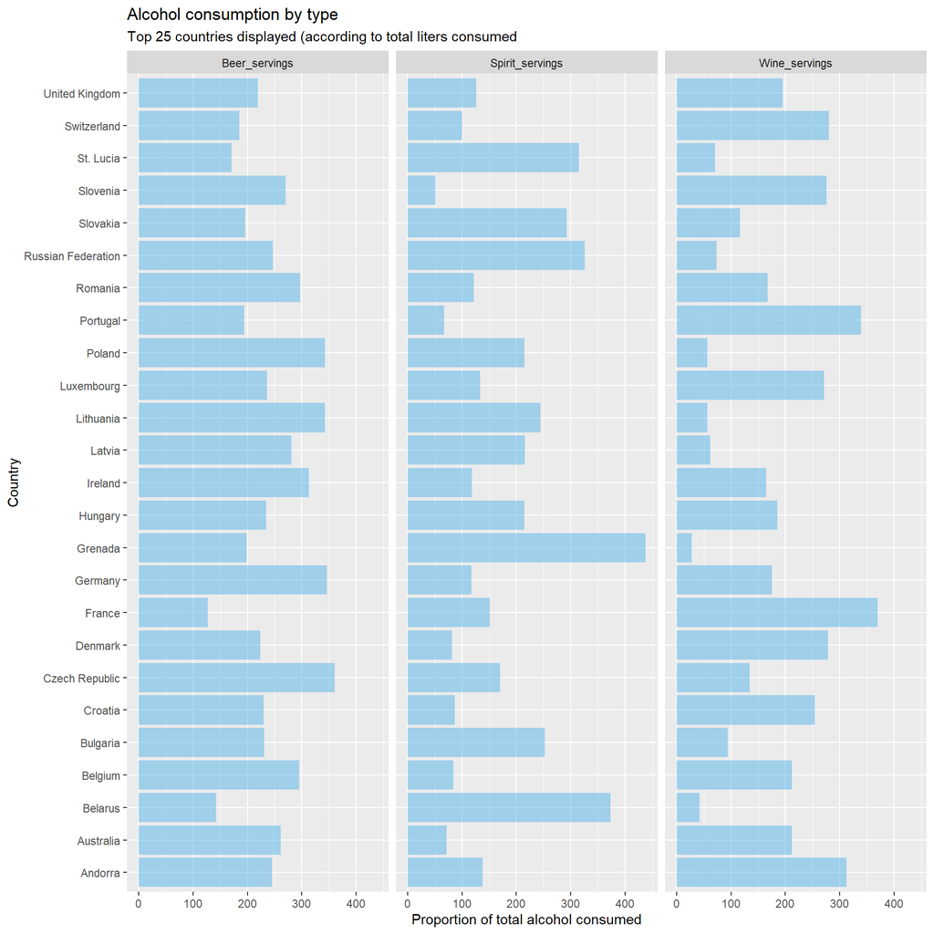